# Robust Standard Error Tutorial

```r
library(lmtest)
library(sandwich)
library(stargazer)
library(dplyr)
```

We’ll use the built-in mtcars dataset, which includes data on 32 car models We define the following variables:

Variable Description Type mpg Miles per gallon (fuel efficiency) Continuous (response variable) wt Weight of car (in 1000 lbs) Continuous hp Gross horsepower Continuous disp Engine displacement (cubic inches) Continuous qsec Number of seconds it takes to drive a quarter mile. Continuous

```r
glimpse(mtcars)
```

```
## Rows: 32
## Columns: 11
## $ mpg  <dbl> 21.0, 21.0, 22.8, 21.4, 18.7, 18.1, 14.3, 24.4, 22.8, 19.2, 17.8,…
## $ cyl  <dbl> 6, 6, 4, 6, 8, 6, 8, 4, 4, 6, 6, 8, 8, 8, 8, 8, 8, 4, 4, 4, 4, 8,…
## $ disp <dbl> 160.0, 160.0, 108.0, 258.0, 360.0, 225.0, 360.0, 146.7, 140.8, 16…
## $ hp   <dbl> 110, 110, 93, 110, 175, 105, 245, 62, 95, 123, 123, 180, 180, 180…
## $ drat <dbl> 3.90, 3.90, 3.85, 3.08, 3.15, 2.76, 3.21, 3.69, 3.92, 3.92, 3.92,…
## $ wt   <dbl> 2.620, 2.875, 2.320, 3.215, 3.440, 3.460, 3.570, 3.190, 3.150, 3.…
## $ qsec <dbl> 16.46, 17.02, 18.61, 19.44, 17.02, 20.22, 15.84, 20.00, 22.90, 18…
## $ vs   <dbl> 0, 0, 1, 1, 0, 1, 0, 1, 1, 1, 1, 0, 0, 0, 0, 0, 0, 1, 1, 1, 1, 0,…
## $ am   <dbl> 1, 1, 1, 0, 0, 0, 0, 0, 0, 0, 0, 0, 0, 0, 0, 0, 0, 1, 1, 1, 0, 0,…
## $ gear <dbl> 4, 4, 4, 3, 3, 3, 3, 4, 4, 4, 4, 3, 3, 3, 3, 3, 3, 4, 4, 4, 3, 3,…
## $ carb <dbl> 4, 4, 1, 1, 2, 1, 4, 2, 2, 4, 4, 3, 3, 3, 4, 4, 4, 1, 2, 1, 1, 2,…
```

- Heavy car = worse fuel efficiency (model 1)
- model 2 capture the interaction of the variables

```r
# Model 1: Simple model
model1 <- lm(mpg ~ wt, data = mtcars)
summary(model1)
```

```
##
## Call:
## lm(formula = mpg ~ wt, data = mtcars)
##
## Residuals:
##     Min      1Q  Median      3Q     Max
## -4.5432 -2.3647 -0.1252  1.4096  6.8727
##
## Coefficients:
##             Estimate Std. Error t value Pr(>|t|)
## (Intercept)  37.2851     1.8776  19.858  < 2e-16 ***
## wt           -5.3445     0.5591  -9.559 1.29e-10 ***
## ---
## Signif. codes:  0 '***' 0.001 '**' 0.01 '*' 0.05 '.' 0.1 ' ' 1
##
## Residual standard error: 3.046 on 30 degrees of freedom
## Multiple R-squared:  0.7528, Adjusted R-squared:  0.7446
## F-statistic: 91.38 on 1 and 30 DF,  p-value: 1.294e-10
```

```r
# Model 2: Interaction between weight and horsepower
model2 <- lm(mpg ~ wt + hp + qsec + wt:hp, data = mtcars)
summary(model2)
```

```
##
## Call:
## lm(formula = mpg ~ wt + hp + qsec + wt:hp, data = mtcars)
##
## Residuals:
##     Min      1Q  Median      3Q     Max
## -3.8243 -1.3980  0.0303  1.1582  4.3650
##
## Coefficients:
##              Estimate Std. Error t value Pr(>|t|)
## (Intercept) 40.310410   7.677887   5.250 1.56e-05 ***
## wt          -8.681516   1.292525  -6.717 3.28e-07 ***
## hp          -0.106181   0.026263  -4.043 0.000395 ***
## qsec         0.503163   0.360768   1.395 0.174476
## wt:hp        0.027791   0.007298   3.808 0.000733 ***
## ---
## Signif. codes:  0 '***' 0.001 '**' 0.01 '*' 0.05 '.' 0.1 ' ' 1
##
## Residual standard error: 2.117 on 27 degrees of freedom
## Multiple R-squared:  0.8925, Adjusted R-squared:  0.8766
## F-statistic: 56.05 on 4 and 27 DF,  p-value: 1.094e-12
```

**Discuss the following plots in terms of zero conditional mean, homoscedasticity, and outliers/influence.**

Plots for Model 1

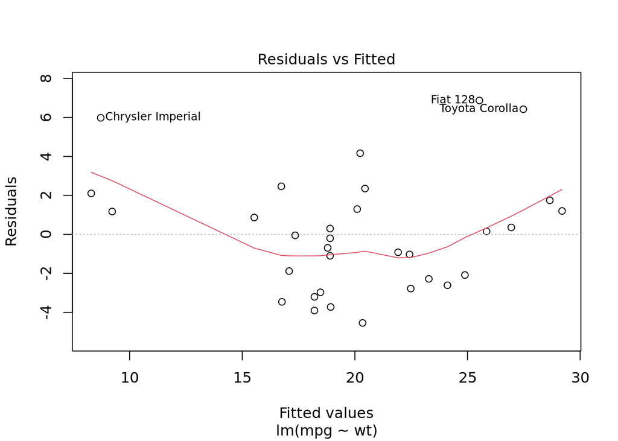

```r
plot(model1, 1)
```

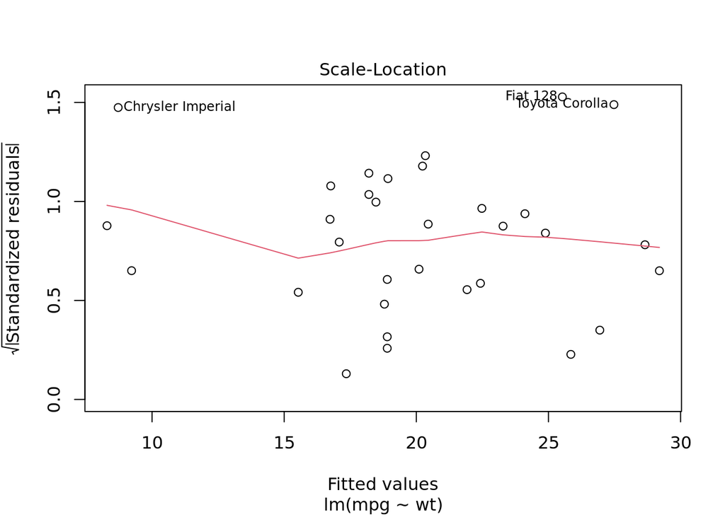

```r
plot(model1, 3)
```

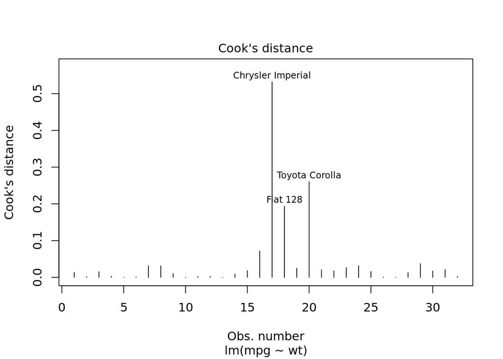

```r
plot(model1, 4)
```

The zero conditional mean is not met because the red line shows that the conditional mean varies because of the outliers. In terms of the homoscedasticity the spread of the residual is varied within the middle, however, overall it met the homoscedasticity condition. The cook’s distance 0.125 -> 3 cars in the outliear. Independent condition -> different standard -> national difference. Scale location -> homoscedasticity vs heteroscedasticity.

Plots for Model 2

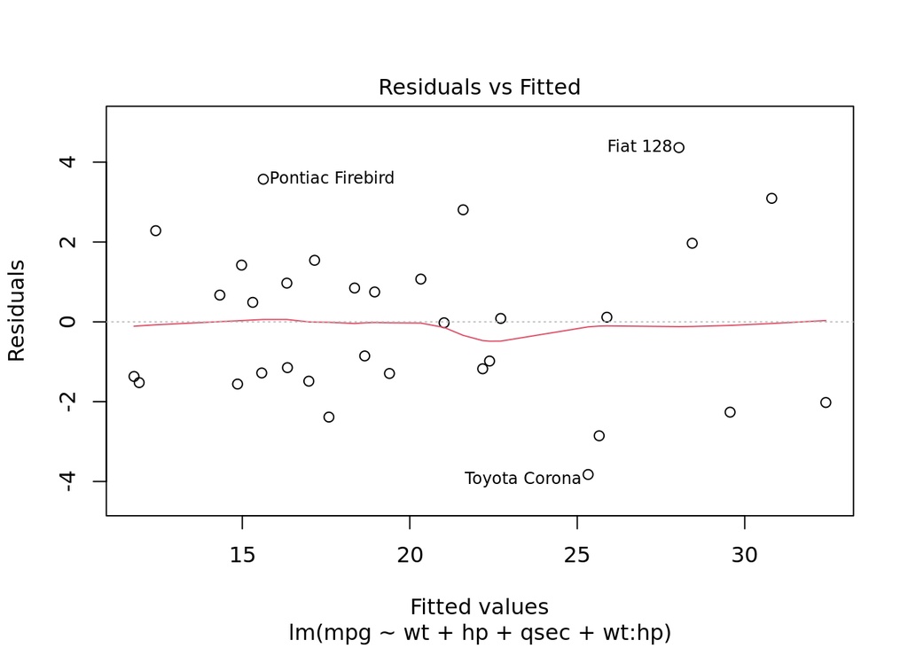

```r
plot(model2, 1)
```

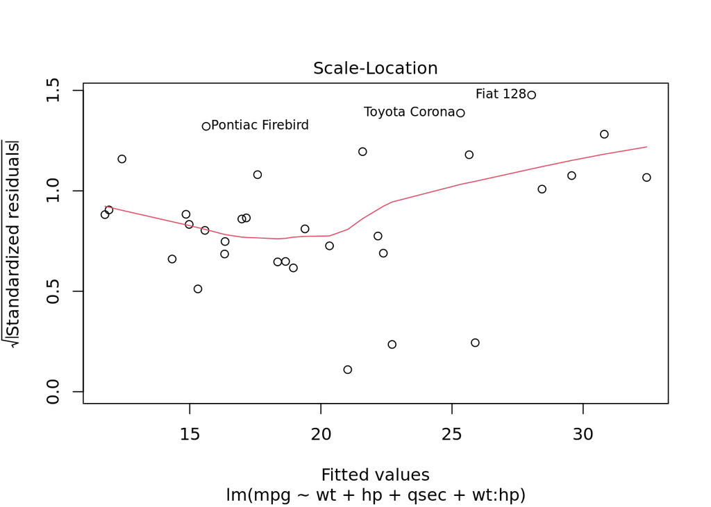

```r
plot(model2, 3)
```

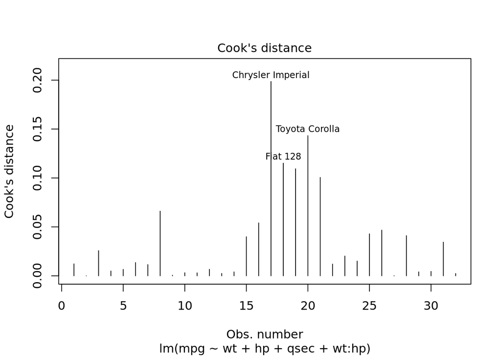

```r
plot(model2, 4)
```

The zero conditional mean is met because the red line shows that the conditional mean slightly different between 20-25. In terms of the homoscedasticity the spread of the residual quite smiliar to say it met the homoscedasticity condition.

**Discuss the Breusch Pagan Test Results**

```r
bptest(model1)
```

```
##
##  studentized Breusch-Pagan test
##
## data:  model1
## BP = 0.040438, df = 1, p-value = 0.8406
```

```r
bptest(model2)
```

```
##
##  studentized Breusch-Pagan test
##
## data:  model2
## BP = 7.0512, df = 4, p-value = 0.1332
```

According to th Breusch-Pagan test, both of the model 1 and 2 cannot reject the null hypothesis, suggesting that models don’t show he heteroscedasticity. We can use robust standard error -> different variance and corvariance matrix

**Using coeftest (sandwich package) we will now use robust standard errors. Compare to initial models.** **What changed? What didn’t?**

```r
coeftest(model1, vcov = vcovHC(model1, type = "HC3"))
```

```
##
## t test of coefficients:
##
##             Estimate Std. Error t value  Pr(>|t|)
## (Intercept) 37.28513    2.42678 15.3640 9.253e-16 ***
## wt          -5.34447    0.73811 -7.2408 4.636e-08 ***
## ---
## Signif. codes:  0 '***' 0.001 '**' 0.01 '*' 0.05 '.' 0.1 ' ' 1
```

```r
coeftest(model2, vcov = vcovHC(model2, type = "HC3"))
```

```
##
## t test of coefficients:
##
##               Estimate Std. Error t value  Pr(>|t|)
## (Intercept) 40.3104098  5.9110323  6.8195 2.520e-07 ***
## wt          -8.6815158  1.6457527 -5.2751 1.455e-05 ***
## hp          -0.1061807  0.0301137 -3.5260  0.001528 **
## qsec         0.5031633  0.2853855  1.7631  0.089200 .
## wt:hp        0.0277913  0.0092135  3.0164  0.005520 **
## ---
## Signif. codes:  0 '***' 0.001 '**' 0.01 '*' 0.05 '.' 0.1 ' ' 1
```

**Now let’s make it pretty with stargazer**

```r
se_conventional <- sqrt(diag(vcov(model1))) ## calculating SE as usual
se_robust       <- sqrt(diag(vcovHC(model2, type = "HC3"))) ## calculating robust SE


html_out <- capture.output(
  stargazer(model1, model2,
    type = "html",
    title = "Two OLS Models (Robust HC3 SEs)",
    dep.var.labels = "Miles per Gallon (mpg)",
    column.labels = c("Model 1: mpg ~ wt", "Model 2: + hp + qsec + wt:hp"),
    #covariate.labels = c("Weight (1000 lbs)", "Horsepower", "1/4 mile time (sec)", "wt × hp"),
    se = list(se_conventional, se_robust),
    keep.stat = c("n","rsq","adj.rsq","f")
  )
)
cat(paste(html_out, collapse = "\n"))
```

|  | *Dependent variable:* |  |
| --- | --- | --- |
|  | Miles per Gallon (mpg) |  |
|  | Model 1: mpg ~ wt | Model 2: + hp + qsec + wt:hp |
|  | (1) | (2) |
| wt | -5.344*** | -8.682*** |
|  | (0.559) | (1.646) |
| hp |  | -0.106*** |
|  |  | (0.030) |
| qsec |  | 0.503* |
|  |  | (0.285) |
| wt:hp |  | 0.028*** |
|  |  | (0.009) |
| Constant | 37.285*** | 40.310*** |
|  | (1.878) | (5.911) |
| Observations | 32 | 32 |
| R<sup>2</sup> | 0.753 | 0.893 |
| Adjusted R<sup>2</sup> | 0.745 | 0.877 |
| F Statistic | 91.375*** (df = 1; 30) | 56.045*** (df = 4; 27) |
| *Note:* | p<0.1; p<0.05; p<0.01 |  |